Navigation

In Vitro Report

# In Vitro Fit Report

/share/lab_crd/lab_crd/taoli/Project/miningcloneid/oxygen/results/fit_invitro_O2G_buffering_500seed/seed131

Generated: 2026-05-16 04:19:41 EDT

## Fit Summary

| metric | value |
| --- | --- |
| fit_mode | fit_invitro |
| objective_total | 3.863 |
| total_loglik | -3.863 |
| growth_loglik | -0.011 |
| ploidy_loglik | -3.014 |
| flow_loglik | -0.838 |
| growth_loglik_sum | -1.281 |
| ploidy_loglik_sum | -36.166 |
| flow_loglik_sum | -16.753 |
| n_growth | 114 |
| n_growth_observed | 114 |
| n_ploidy_passages | 12 |
| n_kary_cells | 220 |
| n_flow_passages | 20 |
| n_flow_samples | 20 |
| seed | 131 |
| itermax | 500 |
| itermax_requested | 500 |
| itermax_max | 500 |
| de_reltol | 1.000e-04 |
| de_steptol | 25 |
| NP_requested | 80 |
| NP_used | 220 |
| n_cores_requested | 22 |
| n_cores_used | 22 |
| misseg_loss_survival | buffering |
| parameter_table | /share/lab_crd/lab_crd/taoli/Project/miningcloneid/oxygen/data/O2G_supply_demand/parameter_table_invitro_buffering.csv |
| fit_objects_dir | /share/lab_crd/lab_crd/taoli/Project/miningcloneid/oxygen/ploidyOxygen/data/fit_objects |
| flow_density_path | /share/lab_crd/lab_crd/taoli/Project/miningcloneid/oxygen/data/g0g1_ploidy_density_grid.csv |

## Best Parameters

### Fitted Parameters

| parameter | parameter_description | value |
| --- | --- | --- |
| lam_min | baseline division rate lam_min in day^-1 | 0.800 |
| lam_max | maximum division rate lam_max in day^-1 | 1.500 |
| k_o | baseline growth saturation scale in percent O2 | 6.026 |
| p_misseg | stress-linked missegregation amplification scale | 0.234 |
| k_o_mis | half-saturation scale for death-linked missegregation amplification in day^-1 | 0.003 |
| p_wgd | whole-genome doubling probability | 0.001 |
| alpha_o2 | soft oxygen-mediated high-ploidy growth penalty strength | 0.500 |
| gamma_growth | exponent for the soft oxygen-mediated ploidy growth penalty | 1.500 |
| mu_hp | soft thresholded high-ploidy hypoxia death strength in day^-1 | 1.509e-04 |
| gamma_mu | exponent for high-ploidy hypoxia death above diploid reference | 1.650 |
| O2_crit | Hill critical oxygen scale for the oxygen-response weight | 0.025 |
| n_O | Hill exponent for the oxygen-response weight | 0.228 |
| sigma_growth | shared standard deviation of growth-rate observations in the in vitro likelihood | 0.245 |
| sigma_kary | shared standard deviation of chromosome-count observation error used to smooth the model-predicted N distribution before evaluating the in vitro likelihood | 0.015 |
| init_mean_2N | initial 2N-cohort Gaussian chromosome-count mean from early normoxic karyotypes | 46.187 |
| init_sd_2N | initial 2N-cohort Gaussian chromosome-count SD from early normoxic karyotypes | 3 |
| init_mean_4N | initial 4N-cohort Gaussian chromosome-count mean from early normoxic karyotypes | 85.272 |
| init_sd_4N | initial 4N-cohort Gaussian chromosome-count SD from early normoxic karyotypes | 5.361 |
| p_mis_base | fixed baseline per-chromosome missegregation probability | 1.059e-05 |

### Fixed Parameters Used By Current Mode

| parameter | parameter_description | value |
| --- | --- | --- |
| buffer_smax | maximum per-copy survival factor for symmetric buffering missegregation survival | 1 |
| buffer_beta | ploidy-buffering strength for symmetric missegregation survival | 1.795 |
| buffer_n_exp | ploidy-buffering exponent for symmetric missegregation survival | 3.785 |

## Transformed Parameters

### Fitted Parameters

| transformed_parameter | parameter_description | transformed_value |
| --- | --- | --- |
| log10_lam_min | baseline division rate lam_min in day^-1 | -0.097 |
| log10_lam_max | maximum division rate lam_max in day^-1 | 0.176 |
| log10_k_o | baseline growth saturation scale in percent O2 | 0.780 |
| log10_p_misseg | stress-linked missegregation amplification scale | -0.631 |
| log10_k_o_mis | half-saturation scale for death-linked missegregation amplification in day^-1 | -2.459 |
| log10_p_wgd | whole-genome doubling probability | -3 |
| log10_alpha_o2 | soft oxygen-mediated high-ploidy growth penalty strength | -0.301 |
| gamma_growth | exponent for the soft oxygen-mediated ploidy growth penalty | 1.500 |
| log10_mu_hp | soft thresholded high-ploidy hypoxia death strength in day^-1 | -3.821 |
| gamma_mu | exponent for high-ploidy hypoxia death above diploid reference | 1.650 |
| log10_O2_crit | Hill critical oxygen scale for the oxygen-response weight | -1.608 |
| n_O | Hill exponent for the oxygen-response weight | 0.228 |
| log10_p_mis_base | fixed baseline per-chromosome missegregation probability | -4.975 |
| log10_sigma_growth | shared standard deviation of growth-rate observations in the in vitro likelihood | -0.612 |
| log10_sigma_kary | shared standard deviation of chromosome-count observation error used to smooth the model-predicted N distribution before evaluating the in vitro likelihood | -1.834 |
| init_mean_2N | initial 2N-cohort Gaussian chromosome-count mean from early normoxic karyotypes | 46.187 |
| log10_init_sd_2N | initial 2N-cohort Gaussian chromosome-count SD from early normoxic karyotypes | 0.477 |
| init_mean_4N | initial 4N-cohort Gaussian chromosome-count mean from early normoxic karyotypes | 85.272 |
| log10_init_sd_4N | initial 4N-cohort Gaussian chromosome-count SD from early normoxic karyotypes | 0.729 |

### Fixed Parameters Used By Current Mode

| transformed_parameter | parameter_description | transformed_value |
| --- | --- | --- |
| buffer_smax | maximum per-copy survival factor for symmetric buffering missegregation survival | 1 |
| log10_buffer_beta | ploidy-buffering strength for symmetric missegregation survival | 0.254 |
| log10_buffer_n_exp | ploidy-buffering exponent for symmetric missegregation survival | 0.578 |

## 3.1 Identifiability Diagnostics

### Figure 1.1 Identifiability Diagnostics

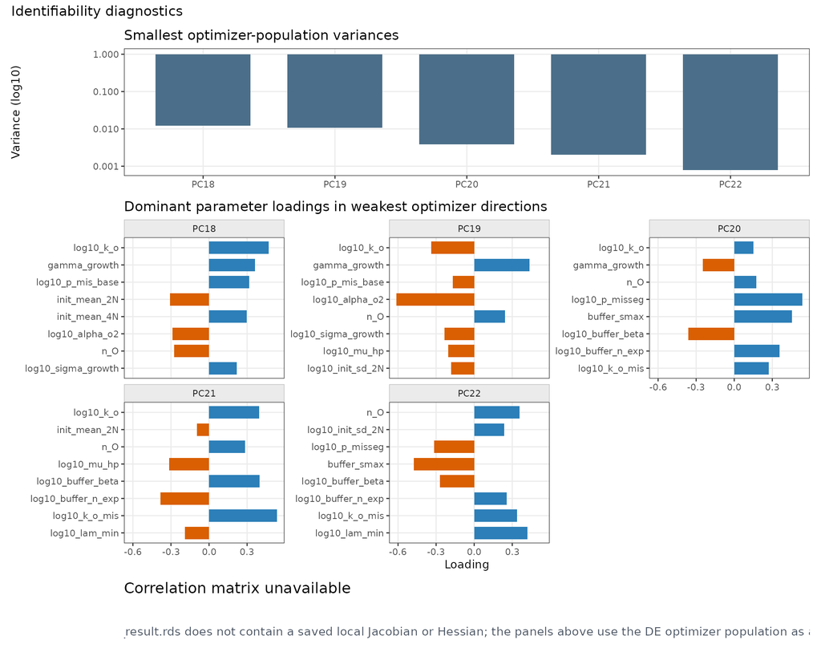

Local identifiability output for the current seed when available. If no Jacobian/Hessian was saved, the figure reports an optimizer-population proxy instead.

Embedded PDF source

## 3.2 Rate-Function Diagnostics

### Figure 2.1/2.4 Constant External Oxygen and Selected-Day Live Cells

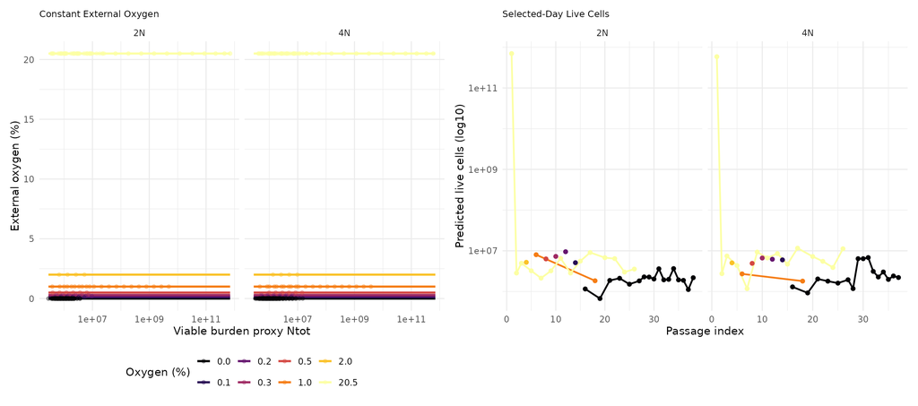

Left panel shows constant external oxygen settings used by the in vitro runner. Right panel shows selected-day predicted live cells. The two panels share the oxygen legend.

Embedded PDF source

### Figure 2.2 Rate-Function Diagnostics

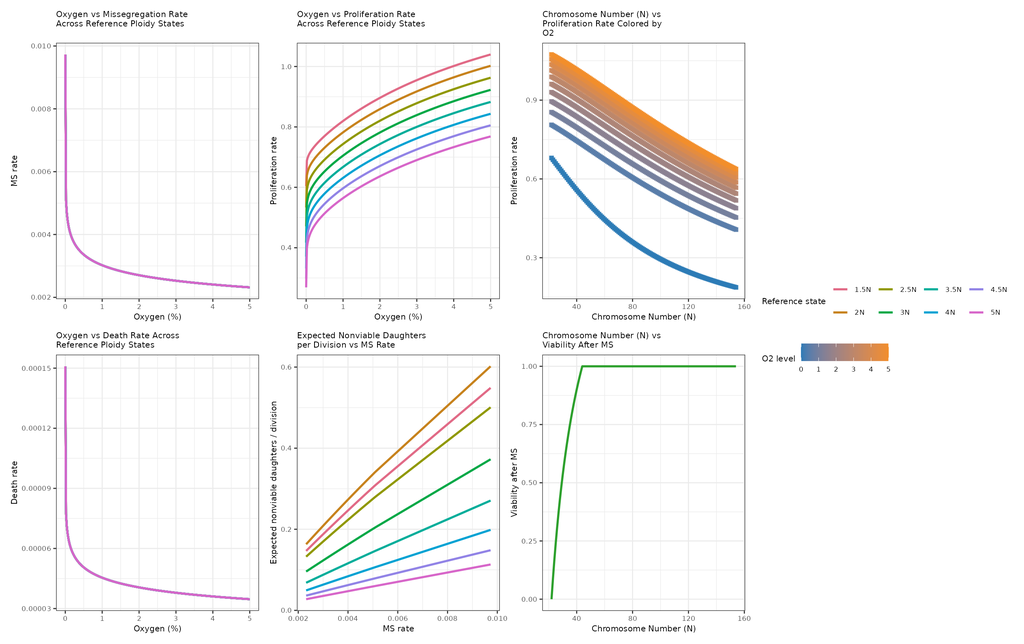

Best-fit oxygen, ploidy, death, proliferation, and missegregation rate functions for the current seed.

Embedded PDF source

### Figure 2.3 Daily Live-Cell Trajectories

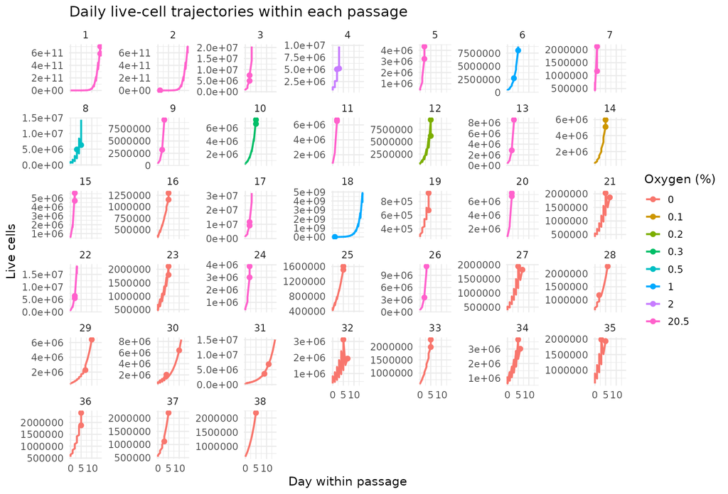

Predicted live-cell trajectories within each passage; selected propagation days are marked.

Embedded PDF source

### Figure 2.5 Growth Rate Fit

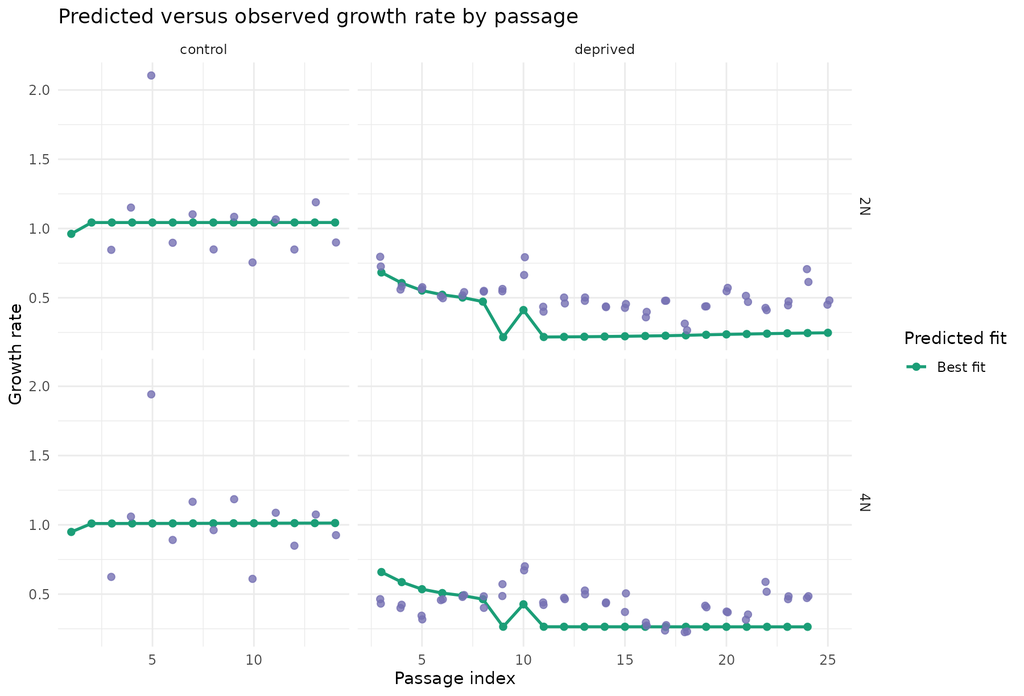

Observed passage growth is overlaid with the fitted in vitro trajectory.

Embedded PDF source

### Figure 2.6 Chromosome Count Quantile Fit

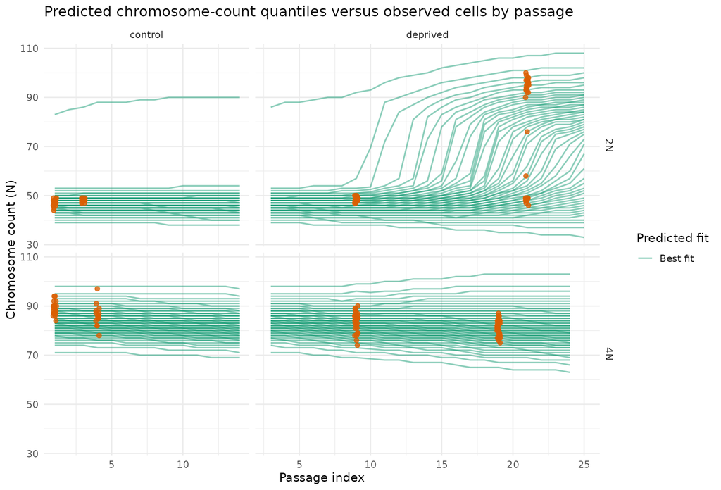

Observed single-cell chromosome counts are overlaid with the fitted chromosome-count quantile trajectories.

Embedded PDF source

### Figure 2.7 Flow-Density Fit

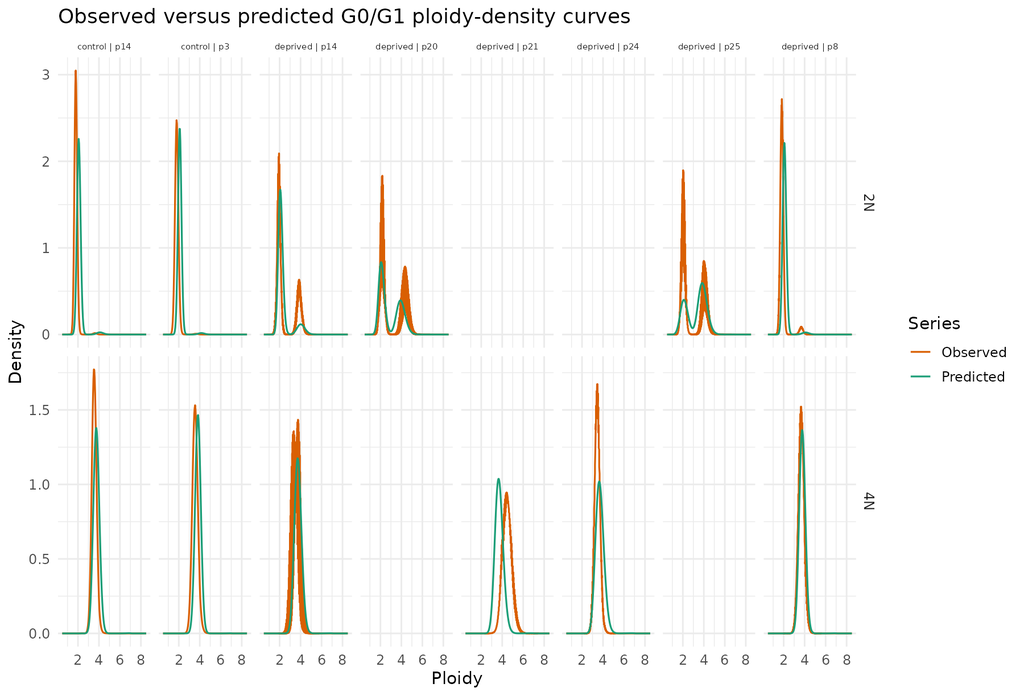

Observed G0/G1 ploidy-density curves are overlaid with the fitted flow-density prediction.

Embedded PDF source

### Figure 2.8 Predicted Ploidy Distribution

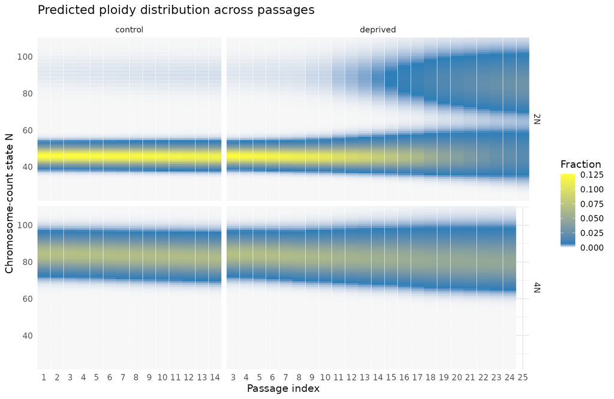

Full predicted chromosome-count distribution across in vitro passages.

Embedded PDF source